# Data Science I Homework 3

# Question 1

```r
#load the necessary packages#

library(tidyverse)
library(ggridges)
library(patchwork)
library(kableExtra)
#load the p8105 dataset and instacart#

library(p8105.datasets)
data("instacart")

#count the amount of times an aisle appears#

instacart %>% count(aisle, sort = TRUE)
```

```
## # A tibble: 134 × 2
##    aisle                              n
##    <chr>                          <int>
##  1 fresh vegetables              150609
##  2 fresh fruits                  150473
##  3 packaged vegetables fruits     78493
##  4 yogurt                         55240
##  5 packaged cheese                41699
##  6 water seltzer sparkling water  36617
##  7 milk                           32644
##  8 chips pretzels                 31269
##  9 soy lactosefree                26240
## 10 bread                          23635
## # ℹ 124 more rows
```

There are about 134aisles in total. The aisle with the most amount of items ordered would be fresh vegetables.

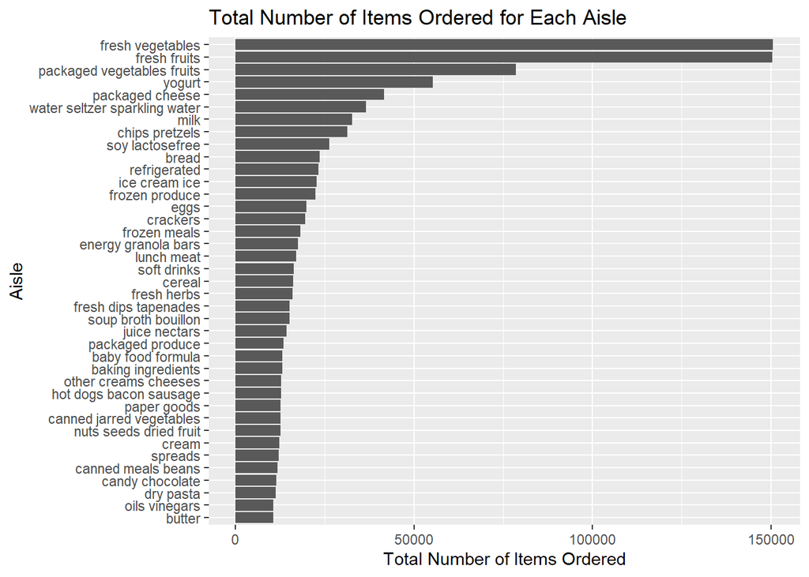

```r
#Produce a plot for the amount of times an item was ordered from an aisle#

instacart |> count(aisle, sort = TRUE) |> filter(n > 10000) |>
  mutate(aisle = reorder(aisle, n)) |> ggplot(aes(x = n, y = aisle)) +
  geom_col() +  labs(title = "Total Number of Items Ordered for Each Aisle", x = "Total Number of Items Ordered", y = "Aisle")
```

The most popular items that are ordered seems to be from aisles that are relevant to necessary groceries. This include not only vegetables and fruits, but also dairy products like milk and cheese. Frozen produce and eggs are also popularly ordered. The less popular items ordered have to do with sugars and additional sources of protein and starch.

```r
#Make a table that shows the amount of times the 3 most popular items were ordered from each aisle#

instacart |> filter(aisle == "packaged vegetables fruits" | aisle == "dog food care" |
                      aisle == "baking ingredients") |>
                      count(aisle, product_name, sort = TRUE) |> group_by(aisle) |>
                      slice_max(order_by = n, n = 3) |>
                      arrange(aisle, n) |>
                      mutate(`Number of Times Ordered` = n) |>
                      select(-n)
```

```
## # A tibble: 9 × 3
## # Groups:   aisle [3]
##   aisle                      product_name                 Number of Times Orde…¹
##   <chr>                      <chr>                                         <int>
## 1 baking ingredients         Cane Sugar                                      336
## 2 baking ingredients         Pure Baking Soda                                387
## 3 baking ingredients         Light Brown Sugar                               499
## 4 dog food care              Small Dog Biscuits                               26
## 5 dog food care              Organix Chicken & Brown Ric…                     28
## 6 dog food care              Snack Sticks Chicken & Rice…                     30
## 7 packaged vegetables fruits Organic Blueberries                            4966
## 8 packaged vegetables fruits Organic Raspberries                            5546
## 9 packaged vegetables fruits Organic Baby Spinach                           9784
## # ℹ abbreviated name: ¹`Number of Times Ordered`
```

Among the three aisles, dog food care has the least amount of items ordered from it. This can be explained by how only a portion of customers own pets–and only a portion own dogs–and thus a smaller proportion of customers would need dog food. With that said, the most popular item in this aisle is Snack Sticks Chicken & Rice Recipe Dog Treats.

Meanwhile, packaged vegetable fruits is the most popular aisle due to how such items do not need further preparation to eat, as opposed to baking ingredients that require work on the customers. The most popular item from this aisle is organic baby spinach. This could be because organic baby spinach can be eaten raw and cooked, giving it more variety. It is also interesting to note that customers seem to prefer raspberries to blueberries.

Finally, among baking ingredients, customer seem to prefer light brown sugar compared to cane sugar. This could be due to how light brown sugar is refined and could give a richer flavor compared to cane sugar.

```r
#produce a reader friendly table for the specific time on the specific day our two products were ordered on average#

instacart |> filter(product_name == "Pink Lady Apples" | product_name == "Coffee Ice Cream") |> mutate(order_dow = case_when(
            order_dow == 0 ~ "Sunday",
            order_dow == 1 ~ "Monday",
            order_dow == 2 ~ "Tuesday",
            order_dow == 3 ~ "Wednesday",
            order_dow == 4 ~ "Thursday",
            order_dow == 5 ~ "Friday",
            order_dow == 6 ~ "Saturday",
          )) |> group_by(product_name, order_dow) |>
          summarize(mean_hour = mean(order_hour_of_day)) |>
          pivot_wider(
            names_from = order_dow,
            values_from = mean_hour
          )
```

```
## # A tibble: 2 × 8
## # Groups:   product_name [2]
##   product_name     Friday Monday Saturday Sunday Thursday Tuesday Wednesday
##   <chr>             <dbl>  <dbl>    <dbl>  <dbl>    <dbl>   <dbl>     <dbl>
## 1 Coffee Ice Cream   12.3   14.3     13.8   13.8     15.2    15.4      15.3
## 2 Pink Lady Apples   12.8   11.4     11.9   13.4     11.6    11.7      14.2
```

Both products seem to be ordered around the afternoon on Friday, Sunday, and Wednesday. However, aside from Friday when Pink Lady Apples is ordered after Coffee Ice Cream, Pink Lady Apples is ordered before Coffee Ice Cream on Sunday and Wednesday. On every other day, while Coffee Ice Cream is still ordered around the afternoon, Pink Lady Apples is ordered around late morning before the noon. This could be because Pink Lady Apples is a fruit and would be in popular demand. Therefore, customers would likely want to order such an item as early as possible. Meanwhile, Coffee Ice Cream would be suited to when the day is hot, which is likely to happen in the afternoon.

# Question 2

```r
#Read the zillow rental price data file#

zillow_price_df = read_csv("./zillow_data/zillow_data/Zip_zori_uc_sfrcondomfr_sm_month_NYC.csv")
#Have a new data variable as ZipCode from the regionname variable#

zillow_price_zip_variation_df = mutate(zillow_price_df, ZipCode = RegionName)

#Clean the data and eliminate StateName, RegionName, RegionType, which are unnecessary data variables#

zillow_clean_price_df = select(zillow_price_zip_variation_df, -`StateName`, -RegionName, -RegionType)
```

```r
#Read the zillow properties data file#

zillow_df = read_csv("./zillow_data/zillow_data/Zip Codes.csv")
#Mutate the CountyName variable from "Bronx" to "Bronx County"#

zillow_county_variation_df = mutate(zillow_df, CountyName = paste(County, "County"))

#Eliminate varibles such as State FIPS, County FIPS, and County#

zillow_clean_df = select(zillow_county_variation_df, -`State FIPS`, -`County FIPS`, -County)
```

```r
#Merge the two datasets into a single tidy dataset#

first_single_zillow_df = left_join(zillow_clean_df, zillow_clean_price_df)
first_clean_single_zillow_df = arrange(first_single_zillow_df, RegionID)

#Use pivot longer to see rental price for each year and month for each zip code#

pivot_longer_single_zillow_df = pivot_longer(
  first_clean_single_zillow_df, cols = starts_with("20"),
  names_to = "Date",
  values_to = "Rental Price"
)

#make a table that shows how many times a zip code is observed#

not_na_pivot_longer_zillow_df = pivot_longer_single_zillow_df %>% drop_na(`Rental Price`)
is_na_pivot_longer_zillow_df = pivot_longer_single_zillow_df %>% filter(is.na(`Rental Price`))

not_na_pivot_longer_single_zillow_df =
  not_na_pivot_longer_zillow_df |> count(ZipCode, sort = TRUE)

is_na_pivot_longer_single_zillow_df =
  is_na_pivot_longer_zillow_df |> count(ZipCode, sort = TRUE)

is_na_pivot_longer_single_zillow_df = is_na_pivot_longer_single_zillow_df %>% mutate(n = 0)

combined_zip_code_rental_count_df = bind_rows(is_na_pivot_longer_single_zillow_df, not_na_pivot_longer_single_zillow_df)

counts_of_zip_codes = combined_zip_code_rental_count_df %>% group_by(ZipCode) %>%
  summarise(n = sum(n))

#get the highest counts and lowest counts of zip codes#

highest_counts_of_zip_codes = counts_of_zip_codes %>% filter(n == 116)
lowest_counts_of_zip_codes = counts_of_zip_codes %>% filter(n < 10) %>% arrange(desc(n))
```

The number of ZIP codes that were observed for all 116 months is 48. Meanwhile, the number of ZIP codes that were observed for fewer than 10 months is 197. A lot of the zip codes that were observed rarely are located in areas of NYC that host a lot of business. Therefore, these properties would likely not have rental prices, as these buildings would already be occupied for various companies. Meanwhile, other zip codes that are observed each month take place in locations such as upper Manhattan and Brooklyn, where residential buildings would be more concentrated in.

```r
Year_pivot_longer_df = separate(pivot_longer_single_zillow_df,
                                Date, into = c("Year", "Month", "Day"), sep = "-")

Year_1_pivot_longer_df = Year_pivot_longer_df |> mutate(Year = strtoi(Year))

#Create table that shows mean rental price for all boroughs#

Year_Borough_df = Year_1_pivot_longer_df |> drop_na(`Rental Price`) |> group_by(Year, CountyName) |>
  summarize(mean_rental_price = mean(`Rental Price`, na.rm = TRUE)) |> arrange(CountyName)
Year_Borough_df
```

```
## # A tibble: 45 × 3
## # Groups:   Year [10]
##     Year CountyName   mean_rental_price
##    <int> <chr>                    <dbl>
##  1  2015 Bronx County             1760.
##  2  2016 Bronx County             1520.
##  3  2017 Bronx County             1544.
##  4  2018 Bronx County             1639.
##  5  2019 Bronx County             1706.
##  6  2020 Bronx County             1811.
##  7  2021 Bronx County             1858.
##  8  2022 Bronx County             2054.
##  9  2023 Bronx County             2285.
## 10  2024 Bronx County             2497.
## # ℹ 35 more rows
```

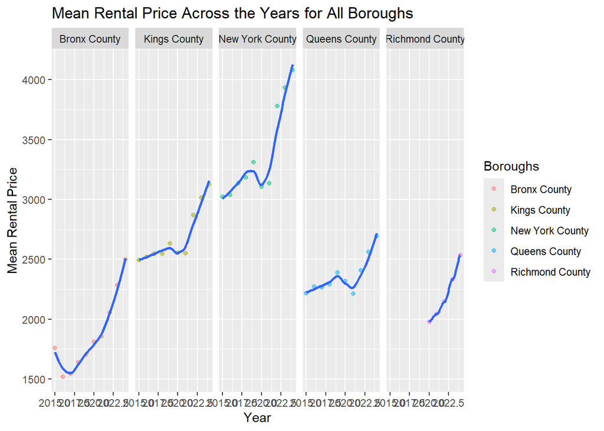

```r
ggplot(Year_Borough_df, aes(x = Year, y = mean_rental_price)) + geom_point(aes(color = CountyName), alpha = 0.5) +
  geom_smooth(se = FALSE) + facet_grid(.~CountyName) + labs(title = "Mean Rental Price Across the Years for All Boroughs", x = "Year", y = "Mean Rental Price", color = "Boroughs")
```

In each of the boroughs, it seems like the mean rental price increases from 2015 to 2024. For New York, Kings, and Queens County from 2019 to 2021, there seems to be a time when the rental price stayed relatively unchanged or even decreased. This would make sense, as 2020 was the start of the pandemic and therefore the demand for properties would have decreased, decreasing the mean rental price for that year.

```r
Zip_Code_Rent_Year_df = Year_pivot_longer_df |> mutate(Year = strtoi(Year))

#Get rental price for every zip code that is observed#

Zip_Code_Rent_df = Zip_Code_Rent_Year_df |> group_by(Year, ZipCode, CountyName, Month) |> summarize(rental_price = `Rental Price`, na.rm = TRUE)
```

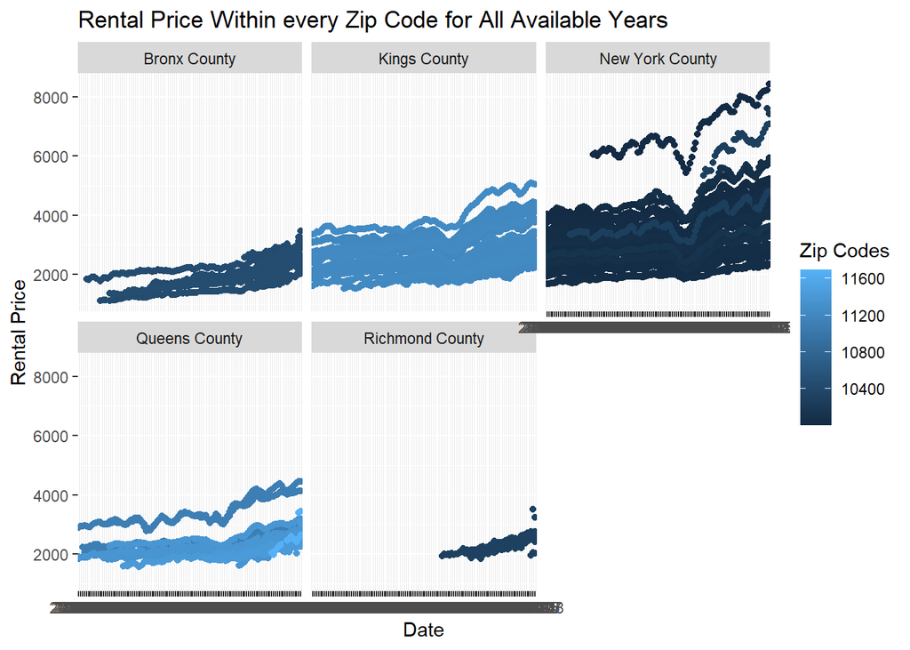

```r
Zip_Code_Rent_df = Zip_Code_Rent_df %>% mutate(Date = paste(as.character(Year), as.character(Month), sep = "-"))

#separate data based on county name and plot it#

every_rent_zip_code = ggplot(Zip_Code_Rent_df, aes(x = Date, y = rental_price)) + geom_point(aes(color = ZipCode)) + facet_wrap(~CountyName) + labs(title = "Rental Price Within every Zip Code for All Available Years", x = "Date", y = "Rental Price", color = "Zip Codes")

every_rent_zip_code
```

```r
#separate data based on zip code and export it to plot#

p = ggplot(Zip_Code_Rent_df, aes(x = Date, y = rental_price)) + geom_point(aes(color = CountyName), alpha = 0.5) + facet_wrap(~ZipCode) + labs(title = "Rental Price Within every Zip Code for All Available Years", x = "Date", y = "Rental Price", color = "Corresponding Borough")

ggsave("Results/zip_codes_borough.png", plot = p, width = 30, height = 20, limitsize = FALSE)
```

After filtering out the zip codes and properties that were missing values for rental prices, we observe the same trend of all properties across boroughs increasing. The lack of data for earlier dates in Richmond County could be attributed to how Staten Island may have had properties that lacked units for rent. It is also notable that with properties in New York County, there was a sharp decrease in the rental price among many zip codes from the year 2019 to 2020. Again, this could be attributed to the COVID-19 pandemic.

```r
Twenty_Twenty_Three_Zip_Code_rent_df = Zip_Code_Rent_Year_df |> filter(Year == 2023) |> group_by(ZipCode, CountyName) |>  summarize(mean_rental_price = mean(`Rental Price`)) |> drop_na(mean_rental_price)
```

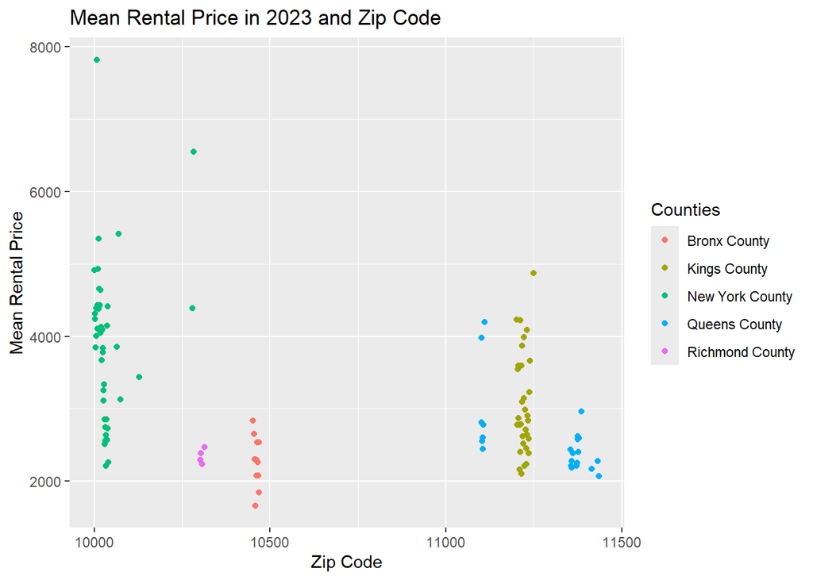

```r
#make the plot that displays distribution of mean rental price over 2023 for zip codes#

ggplot(Twenty_Twenty_Three_Zip_Code_rent_df, aes(x = ZipCode, y = mean_rental_price)) + geom_point(aes(color = CountyName), alpha = 1) + labs(title = "Mean Rental Price in 2023 and Zip Code", x = "Zip Code", y = "Mean Rental Price", color = "Counties")
```

For the zip codes in New York County in 2023, the mean rental price has a much larger dispersion compared to other boroughs. Specifically, it has a couple of data points that have a mean rental price larger than 6,000 dollars per month. Overall, it seems like New York County has a higher mean rental price in 2023 compared to other boroughs.

The second highest mean rental price belongs to Kings County, which lines up with the trend observed for other years. It also lines up with the mean rental price across all years for the boroughs.

Finally, the mean rental price over 2023 for Bronx County, Richmond County, and Queens County is overall similar. It is notable that even in 2023, Richmond County has significantly less observations compared to all other boroughs.

```r
mean_rent_zip_code_2023_plot = ggplot(Twenty_Twenty_Three_Zip_Code_rent_df, aes(x = ZipCode, y = mean_rental_price)) + geom_point(aes(color = CountyName))

combined_plot = every_rent_zip_code/mean_rent_zip_code_2023_plot

ggsave("Results/nyc_combined_rental_trend.png", plot = combined_plot, width = 30, height = 20, limitsize = FALSE)
```

# Question 3

```r
#read our datasets#

nhane_covar_df = read_csv("./Problem_3_Datasets/nhanes_covar.csv")
```

```
## ──────────────────────────────────────────────────────── Delimiter: "," chr
## (5): ...1, 1 = male, ...3, ...4, 1 = Less than high school
```

```r
nhane_accel_df = read_csv("./Problem_3_Datasets/nhanes_accel.csv")
#clean, tidy, and merge our datasets#

nhane_covar_clean_variable_df = nhane_covar_df |> mutate(SEQN = `...1`, sex = `1 = male`,
                                                      age = `...3`, BMI = `...4`,
                                                      education = `1 = Less than high school`) |>
  select(-`...1`, -`1 = male`, -`...3`, -`...4`, -`1 = Less than high school`) |> drop_na(SEQN, sex, age, BMI, education) |> filter(age >= 21) |> filter(SEQN != "SEQN") |> mutate(
    sex = case_when(
      sex == 1 ~ "male",
      sex == 2 ~ "female"
    ),
    education = case_when(
      education == 1 ~ "Less than high school",
      education == 2 ~ "High school equivalent",
      education == 3 ~ "More than high school"
    ),
    SEQN = as.numeric(SEQN), age = as.numeric(age), BMI = as.numeric(BMI)
  )

full_nhane_joint_data_df = left_join(nhane_covar_clean_variable_df, nhane_accel_df)
#create table based on education and sex#

table_sex_education_distribution = full_nhane_joint_data_df |> group_by(sex, education) |>
  summarise(n = n()) |> pivot_wider(names_from = sex, values_from = n)
```

[output not shown]

```r
table_sex_education_distribution
```

```
## # A tibble: 3 × 3
##   education              female  male
##   <chr>                   <int> <int>
## 1 High school equivalent     23    35
## 2 Less than high school      28    27
## 3 More than high school      59    56
```

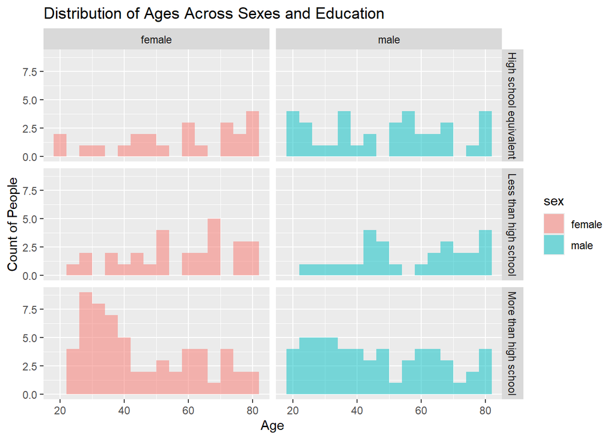

```r
#Create distribution of counts of people for all ages#

ggplot(full_nhane_joint_data_df, aes(x = age, fill = sex)) + geom_histogram(binwidth = 4, alpha = 0.5) +
  facet_grid(education~sex) + labs(title = "Distribution of Ages Across Sexes and Education", x = "Age", y = "Count of People", color = "Sex")
```

For the participants with more than high school education, the distribution of ages is skewed right for female participants compared to male participants. This could be because how higher education was historically dominated by male students and only relatively recently is education being implemented more broadly across all sexes.

Meanwhile, the distribution of ages for less than high school education is relatively concentrated around ages 45, 70,and 80 for male participants, while the distribution for female participants in the same education level is more uniform. The distribution for male participants can be explained by how older participants may have come from a time when people had less resources to study and attend higher education. Overall, the total number of participants with this education level is similar for both sexes.

Finally, the distribution of ages for an education of high school equivalent is relatively uniform for both sexes. However, from the table, we see that the total number of male participants are much higher than female participants in this education level.

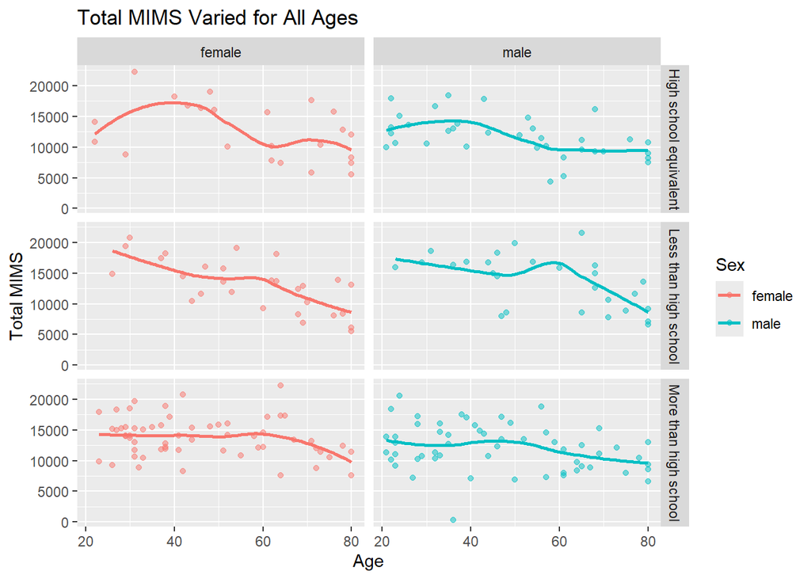

```r
#plot the total MIMS over all ages for sex and education levels#

total_MIMS_df = full_nhane_joint_data_df |> pivot_longer(cols = starts_with("min"),
                                                        names_to = "MIMS", values_to = "MIMS amount") |>
  group_by(SEQN, sex, age, education) |> summarise(Total_MIMS = sum(`MIMS amount`))
ggplot(total_MIMS_df, aes(x = age, y = Total_MIMS, color = sex)) + geom_point(alpha = 0.5) +
  geom_smooth(se = FALSE) + facet_grid(education~sex)+ labs(title = "Total MIMS Varied for All Ages", x = "Age", y = "Total MIMS", color = "Sex")
```

For education levels, the total MIMS has an overall negative correlation with age. For less than high school education, the total MIMS for all ages is rather consistent between the sexes. However, for high school equivalent education, there is an actual increase in total MIMS from ages 20 to 40 for both male and female participants. The total MIMS for female participants around age 40 is also significantly higher than male participants. Finally, for more than high school education, the total MIMS for female participants is higher than male participants by a bit for all ages.

```r
#create a new dataset to transform each minute to their corresponding hour#

time_minute_average_df = full_nhane_joint_data_df |> pivot_longer(cols = starts_with("min"),
                                                        names_to = "MIMS", values_to = "MIMS amount") |>
  mutate(minute = as.numeric(str_extract(MIMS, "\\d+")), hour = minute %/% 60) |> group_by(hour, sex, education) |> summarise(Mean_MIMS = mean(`MIMS amount`))
```

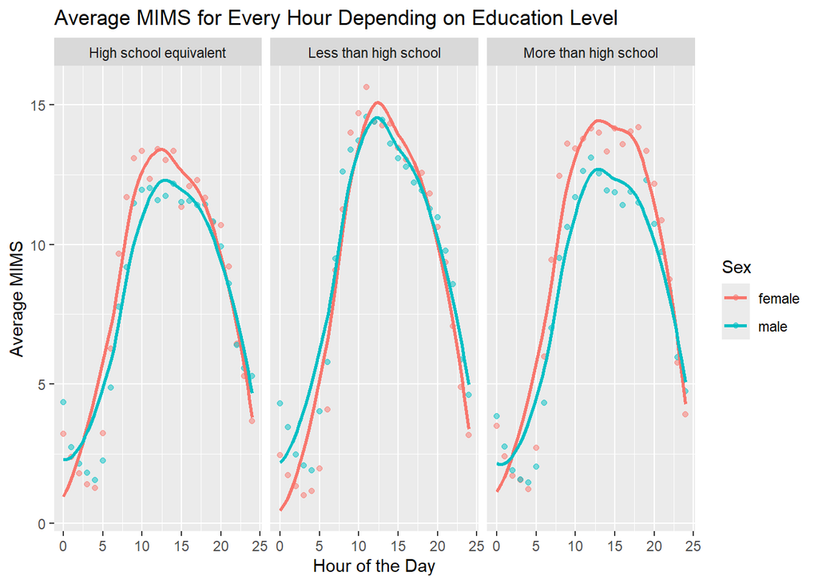

```r
#Plot out the average MIMS vs the hour of the day for all sexes and education levels#

ggplot(time_minute_average_df, aes(x = hour, y = Mean_MIMS, color = sex)) + geom_point(alpha = 0.5) +
  geom_smooth(se = FALSE) + facet_wrap(~education)+ labs(title = "Average MIMS for Every Hour Depending on Education Level", x = "Hour of the Day", y = "Average MIMS", color = "Sex")
```

Overall, it seems that the mean MIMS increases from midnight to around noon of the day, and then decreases from noon to midnight. The more notable differences can be observed between the sexes. For less than high school education, the mean MIMS is similar for both female and male participants. However, for high school equivalent and higher education, the mean MIMS is higher for female participants over male participants.

For higher than high school education, the mean MIMS for female participants is much higher than male participants around the hours of 10 to 20. The same trend can be observed for high school equivalent education, although the discrepancy between the sexes is much smaller. For other hours, the mean MIMS of female participants are only higher than male participants by a percentage at most. Otherwise, the mean MIMS difference is rather insignificant between the sexes.